# FML clustering assignment

2023-11-14

Summary;

### Data Exploration

1. **Data Load and Summary**: Loaded the ‘Pharmaceuticals.csv’ dataset, observed its structure (21 observations, 14 variables), and identified factor variables representing Symbol, Name, Median_Recommendation, Location, and Exchange.
2. **Initial Visualization**: Displayed the structure of the dataset and visualized pairs of numerical variables to observe any potential clusters visually.

### Cluster Analysis Preparation

3. **Data Preprocessing**: Removed factor variables and performed scaling to normalize the data for cluster analysis.
4. **Distance Matrix Calculation**: Computed the distance matrix to measure the dissimilarity between observations.

### Hierarchical Agglomerative Clustering

5. **Complete Linkage Method**: Utilized hierarchical agglomerative clustering with complete linkage to create dendrograms and identified potential clusters based on visual inspection of the dendrogram.
6. **Average Linkage Method**: Conducted hierarchical agglomerative clustering with average linkage to explore alternative clustering structures.

### Cluster Membership and Characterization

7. **Cluster Membership Analysis**: Determined the number of clusters and their membership using both methods, then characterized the clusters by aggregating numerical features and observing silhouette plots for cluster validation.
8. **K-means Clustering**: Performed K-means clustering with k=3 and evaluated cluster qualities using sum of squares and silhouette plots, comparing the results to hierarchical clustering.

### Pattern Analysis and Interpretation

9. **Comparison Across Methods**: Analyzed the patterns within clusters concerning Median_Recommendation, Location, and Exchange across different clustering methodologies.

### Insights for Equities Analyst

10. **Utilization for Equities Analysis**: Explored the implications of the clustering analysis for equities analysts studying the pharmaceutical industry, covering investment strategies, risk assessment, industry insights, investment allocation, strategy adaptation, and risk mitigation.

### Summary and Cluster Insights

11. **Cluster Insights and Naming**:
- Identified three key clusters based on recurring characteristics observed across multiple methodologies.
- Provided insights into stability, global consistency, and investment diversity within these clusters.
12. **Cluster Naming and Rationale**:
- Named clusters based on dominant characteristics observed across methodologies, emphasizing stability, global presence, and investment diversity.

```r
# Data Exploration
df <- read.csv('Pharmaceuticals.csv')
getwd()
```

```
## [1] "C:/Users/Lenovo/OneDrive/Desktop/FML"
```

```r
summary(df)
```

```
##     Symbol              Name             Market_Cap          Beta
##  Length:21          Length:21          Min.   :  0.41   Min.   :0.1800
##  Class :character   Class :character   1st Qu.:  6.30   1st Qu.:0.3500
##  Mode  :character   Mode  :character   Median : 48.19   Median :0.4600
##                                        Mean   : 57.65   Mean   :0.5257
##                                        3rd Qu.: 73.84   3rd Qu.:0.6500
##                                        Max.   :199.47   Max.   :1.1100
##     PE_Ratio          ROE            ROA        Asset_Turnover    Leverage
##  Min.   : 3.60   Min.   : 3.9   Min.   : 1.40   Min.   :0.3    Min.   :0.0000
##  1st Qu.:18.90   1st Qu.:14.9   1st Qu.: 5.70   1st Qu.:0.6    1st Qu.:0.1600
##  Median :21.50   Median :22.6   Median :11.20   Median :0.6    Median :0.3400
##  Mean   :25.46   Mean   :25.8   Mean   :10.51   Mean   :0.7    Mean   :0.5857
##  3rd Qu.:27.90   3rd Qu.:31.0   3rd Qu.:15.00   3rd Qu.:0.9    3rd Qu.:0.6000
##  Max.   :82.50   Max.   :62.9   Max.   :20.30   Max.   :1.1    Max.   :3.5100
##    Rev_Growth    Net_Profit_Margin Median_Recommendation   Location
##  Min.   :-3.17   Min.   : 2.6      Length:21             Length:21
##  1st Qu.: 6.38   1st Qu.:11.2      Class :character      Class :character
##  Median : 9.37   Median :16.1      Mode  :character      Mode  :character
##  Mean   :13.37   Mean   :15.7
##  3rd Qu.:21.87   3rd Qu.:21.1
##  Max.   :34.21   Max.   :25.5
##    Exchange
##  Length:21
##  Class :character
##  Mode  :character
##
##
##
```

The dataset shows 21 observations and it includes 14 variables. The variable number 1,2,12,13 & 14 are factor variables representing Symbol, Name, Median_Recommendation, Location & Exchange. In order to start cluster analysis, we are going to remove the factor variables from our analysis, because cluster analysis is only ment for nonfactor variables or numerical variables.

```r
head(df)
```

```
##   Symbol                Name Market_Cap Beta PE_Ratio  ROE  ROA Asset_Turnover
## 1    ABT Abbott Laboratories      68.44 0.32     24.7 26.4 11.8            0.7
## 2    AGN      Allergan, Inc.       7.58 0.41     82.5 12.9  5.5            0.9
## 3    AHM        Amersham plc       6.30 0.46     20.7 14.9  7.8            0.9
## 4    AZN     AstraZeneca PLC      67.63 0.52     21.5 27.4 15.4            0.9
## 5    AVE             Aventis      47.16 0.32     20.1 21.8  7.5            0.6
## 6    BAY            Bayer AG      16.90 1.11     27.9  3.9  1.4            0.6
##   Leverage Rev_Growth Net_Profit_Margin Median_Recommendation Location Exchange
## 1     0.42       7.54              16.1          Moderate Buy       US     NYSE
## 2     0.60       9.16               5.5          Moderate Buy   CANADA     NYSE
## 3     0.27       7.05              11.2            Strong Buy       UK     NYSE
## 4     0.00      15.00              18.0         Moderate Sell       UK     NYSE
## 5     0.34      26.81              12.9          Moderate Buy   FRANCE     NYSE
## 6     0.00      -3.17               2.6                  Hold  GERMANY     NYSE
```

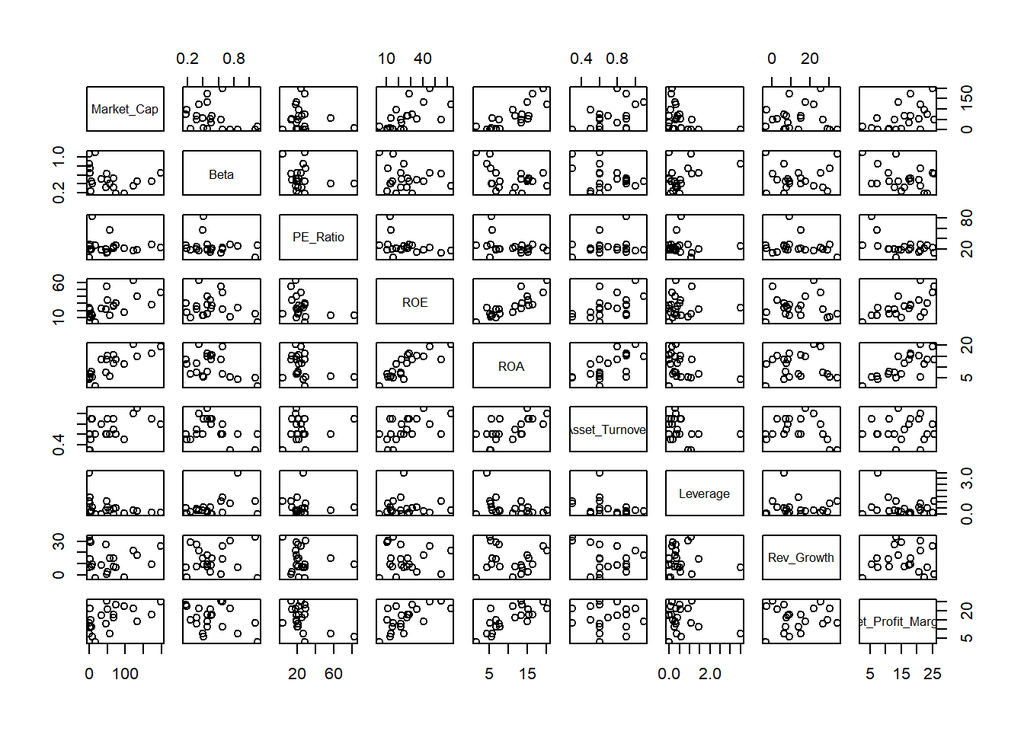

```r
pairs(df[3:11])
```

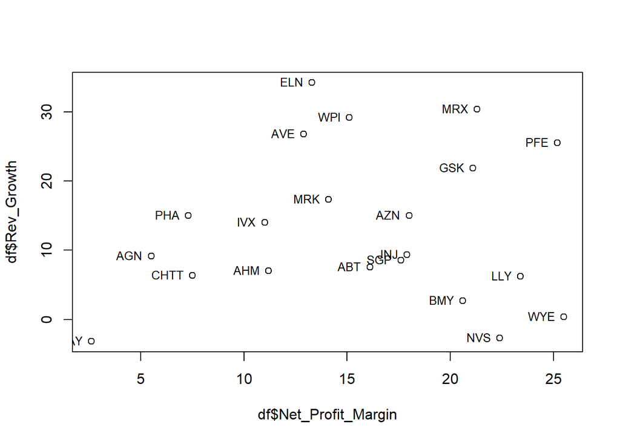

```r
# Scatter plot
plot(df$Rev_Growth~ df$Net_Profit_Margin, df=df)
with(df,text(df$Rev_Growth ~ df$Net_Profit_Margin, labels=df

             $Symbol,pos=2, cex= 0.8))
```

From the depicted graph, focusing on the variables Rev Growth and Net Profit Margin, it’s evident that four companies, represented by symbols in the right bottom corner, share characteristics suggesting the potential to form a cluster. These companies exhibit high net profit margins and low revenue growth. Conversely, in the right top corner, three companies, indicated by symbols, demonstrate both high net profit margins and robust revenue growth, hinting at the possibility of forming another distinct cluster. For the remaining companies, there is some overlap.Lets do cluster analysis .

```r
#Scaling
z = df[, -c(1,2,12,13,14)]
df_scale = scale(z)
df_scale
```

```
##       Market_Cap        Beta    PE_Ratio         ROE        ROA Asset_Turnover
##  [1,]  0.1840960 -0.80125356 -0.04671323  0.04009035  0.2416121      0.0000000
##  [2,] -0.8544181 -0.45070513  3.49706911 -0.85483986 -0.9422871      0.9225312
##  [3,] -0.8762600 -0.25595600 -0.29195768 -0.72225761 -0.5100700      0.9225312
##  [4,]  0.1702742 -0.02225704 -0.24290879  0.10638147  0.9181259      0.9225312
##  [5,] -0.1790256 -0.80125356 -0.32874435 -0.26484883 -0.5664461     -0.4612656
##  [6,] -0.6953818  2.27578267  0.14948233 -1.45146000 -1.7127612     -0.4612656
##  [7,] -0.1078688 -0.10015669 -0.70887325  0.59693581  0.8617498      0.9225312
##  [8,] -0.9767669  1.26308721  0.03299122 -0.11237924 -1.1677918     -0.4612656
##  [9,] -0.9704532  2.15893320 -1.34037772 -0.70899938 -1.0174553     -1.8450624
## [10,]  0.2762415 -1.34655112  0.14948233  0.34502953  0.5610770     -0.4612656
## [11,]  1.0999201 -0.68440408 -0.45749769  2.45971647  1.8389364      1.3837968
## [12,] -0.9393967  0.48409069 -0.34100657 -0.29136529 -0.6979905     -0.4612656
## [13,]  1.9841758 -0.25595600  0.18013789  0.18593083  1.0872544      0.9225312
## [14,] -0.9632863  0.87358895  0.19240011 -0.96753478 -0.9610792     -1.8450624
```

[output cut: 43 more lines]

In order to do the cluster analysis, we need to normalize our dataset to be able to compare them to each other. After that we are going to calculate the distance matrix based on all the variables to see which companies have the lowest distance to each other which will enable them to form the same cluster and which companies have the highest distance which will put them in different clusters.

```r
# Calculate distance matrix
distance = dist(df_scale)
print(distance, digits = 3)
```

```
##       1    2    3    4    5    6    7    8    9   10   11   12   13   14   15
## 2  4.42
## 3  2.02 3.95
## 4  1.67 4.91 2.36
## 5  2.11 4.64 2.49 2.63
## 6  4.69 4.85 3.64 5.07 4.76
## 7  1.81 5.42 2.60 1.57 3.40 5.27
## 8  5.02 5.61 4.76 5.72 5.10 4.97 5.29
## 9  4.90 6.70 4.70 4.97 3.75 4.61 5.38 4.68
## 10 1.42 5.14 3.24 2.41 2.91 5.80 2.19 5.66 5.55
## 11 3.69 6.75 4.90 2.96 4.48 7.55 3.10 7.08 6.73 3.63
## 12 2.62 4.47 2.32 3.28 2.39 3.66 3.28 2.95 3.12 3.54 5.28
## 13 2.33 5.32 3.59 1.96 3.64 5.72 2.51 6.31 6.07 2.72 2.99 4.35
## 14 3.92 5.48 4.12 4.27 2.93 4.85 4.73 4.79 2.39 4.19 6.19 2.83 5.31
## 15 2.68 5.44 3.36 1.86 3.47 5.92 2.43 6.10 5.92 3.38 2.22 4.16 1.81 5.53
## 16 1.92 5.47 3.33 3.06 3.33 5.33 2.87 6.06 5.73 1.58 4.78 3.90 3.08 4.48 4.11
## 17 3.89 6.91 5.27 3.11 4.50 7.16 3.67 7.18 6.12 3.78 2.45 5.36 2.45 5.52 2.83
## 18 2.91 2.37 2.93 3.72 2.72 3.96 4.41 5.00 5.01 3.75 5.77 3.07 4.11 3.83 4.45
## 19 1.31 4.73 1.70 1.08 2.46 4.43 1.48 5.35 4.67 2.21 3.78 2.76 2.60 3.91 2.71
## 20 2.88 5.01 2.94 3.41 1.30 5.06 4.12 5.54 3.76 3.41 5.44 2.86 4.59 2.65 4.57
## 21 3.04 6.45 4.19 3.32 4.25 5.95 2.27 5.13 5.31 2.75 3.67 3.72 3.86 4.71 3.94
##      16   17   18   19   20
## 2
## 3
## 4
## 5
## 6
## 7
## 8
## 9
## 10
## 11
## 12
## 13
## 14
## 15
## 16
## 17 4.54
## 18 3.88 5.59
## 19 2.54 3.96 3.45
## 20 3.63 5.40 3.17 3.03
## 21 3.53 4.03 5.29 3.15 4.92
```

Now that we are ready to perform cluster analysis, we are going to use Hierarchical agglomerative clustering method with Complete Linkage as the first method.

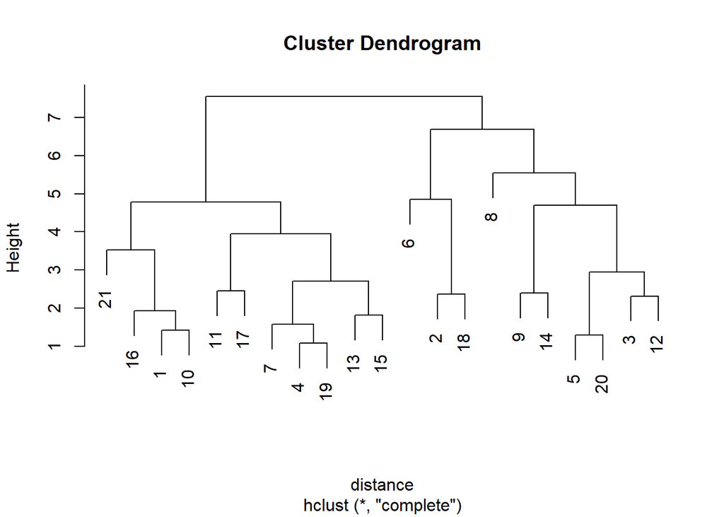

```r
# Hierarchical agglomerative clustering
#Cluster Dendogram with Complete Linkage


hc.c <- hclust(distance)
plot(hc.c)
plot(hc.c,labels=df$Company,main='Cluster Dendrogram')
```

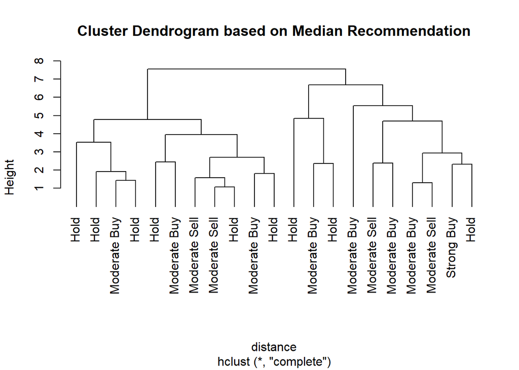

```r
plot(hc.c,hang=-1, labels = df$Median_Recommendation, main='Cluster Dendrogram based on Median Recommendation')
```

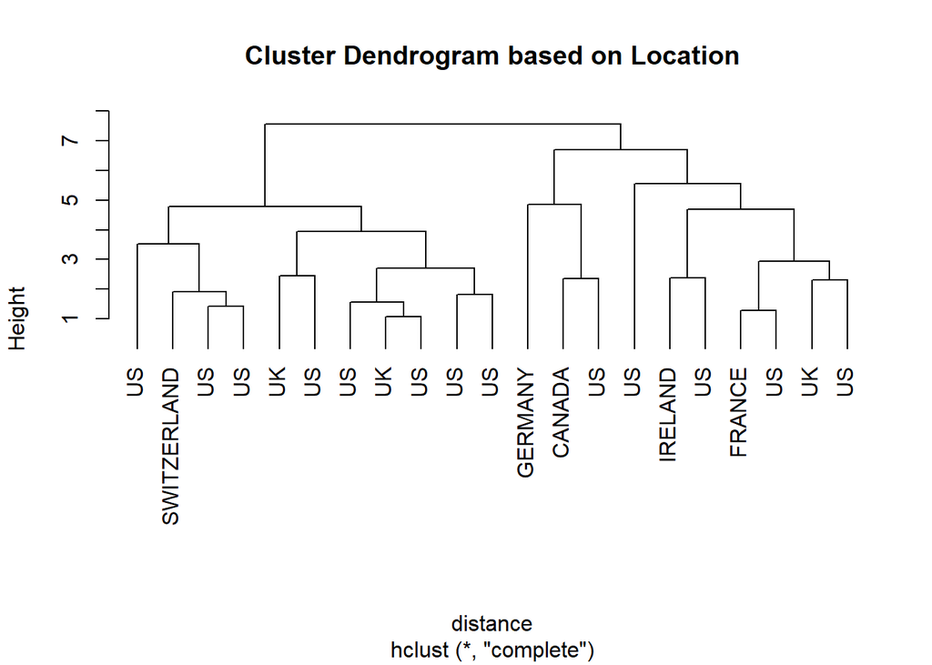

```r
plot(hc.c,hang=-1, labels = df$Location, main='Cluster Dendrogram based on Location')
```

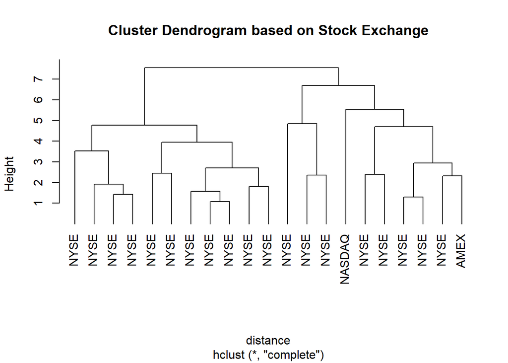

```r
plot(hc.c,hang=-1, labels = df$Exchange, main='Cluster Dendrogram based on Stock Exchange')
```